# Exploring Popularity in Music: A Capstone

Stephanie Sears

8/16/2019

## Introduction

As an Assistant Professor researching and teaching in a Historically Black College and University (HBCU) that offers educational curriculum in liberarl arts and the humanities, I primarily conduct qualitative research. Situated in the academic disciplines of Africana Women’s Studies, Religion and Psychology, I am interested in women’s experiences in society, the religious/spiritual dimensions of everyday experiences, and the psychological consciousness motivating everyday human behavior. My research interests compel me to ask questions about meaning. I am always seeking novel ways to understand and interpret the reasons behind why people do what they do. Thus, my engagement with data science is rooted in my intellectual curiosity to derive meaning from patterns of behavior.

Part of the objective of this capstone project is to demonstrate the usefulness of data science in qualitative studies. Very often, social science research integrates qualitative and quantitative methods to provide a fuller description of a phenomenon. Data science represents an ideal approach in this endeavor, enabling me to analyze unstructured, subjective data (a common source of data in qualitative studies) and potentially replicable or generalizable data (a common research requirement in quantitative studies). Overall, my aim is to analyze and explain narrative associated with numbers!

This capstone project is a text mining and sentiment analysis study. It focuses on the R&B music of Patti LaBelle, Whitney Houston and Mariah Carey. By analyzing social media comments, this project seeks to discover descriptive themes pertinent to popular African American Women R&B singers. Given the salience of the idea of the “diva,” this project seeks to uncover how audiences identify with the top divas of R&B and the ways in which their interactivity with media constructs notions of “the popular.” It uses data science to understand the audience’s interactive behavior that correlates to popularity and aims to build a self-consistent explanation or model that might interpret that behavior.

## Conceptual Background

With the advent of social media metrics such as “likes,” “follows,” “pins,” “shares,” “comments,” and “views,” the everyday connoisseur of culture enjoys a greater stake in the social construction of value. Indeed, cultivating fandom, an effect of the ease in which audiences now express “belonging” and “non-belonging” through mediated platforms, is currently a cultural practice. Its prevalence has transformed how people interact and intersect with popular culture. As it is now possible to become a career “influencer” utilizing social media platforms, it is of profound interest to researchers to examine the ways in which cultural consciousness defines what’s valuable and how such definitions gain considerable social force.

That an influential social force is garnering strength through mediated platforms is no new phenomenon. But the growing importance of popular culture as a context of public persuasion is compelling. In such a context, we witness the transformation of popular expression into impactful commentary that can either launch a public figure into stardom or topple an embattled icon, ensuring a purposively shameful fall from grace. Once relegated a marginal influence, popular culture has became an integral force in the socialization of collective consciousness. As a result, the everyday person participates in the curating of the collective self-image. A vote cast (as a “like”, a “share”, or a “follow,” etc) represents, in many ways, a statement about the collective self-image of society and how social actors want to see themselves evaluated within it.

For example, religious scholar, Robin Sylvan (2002) explores the ways in which popular culture has morphed into a religious phenomenon, particularly as experienced through popular music. He writes,

“Observers of culture and scholars of religion have said many things about the slow decline of religion and the death of God in Western civilization….[R]eligion and God are not dead, but very much alive and well and dancing to the beat of popular music; the religious impulse has simply migrated to another sector of the culture, a sector in which religious sensibilities have flourished and made an enormous impact on a large portion of the population….Yet, because conventional wisdom has taught us to regard popular music as trivial forms of secular entertainment, these religious dimensions remain hidden from view, marginalized and misunderstood” (p. 3).

Sylvan seeks to make explicit the ways in which popular contexts reveal hidden examples of contemporary religiosity. As a result, he raises the value of the notion of “the popular.” As contemporary folks elect a “popular,” they raise new deity forms as well (the popularized one becomes a symbolic totem of the collective self-image). In addition, they reconstitute notions of “the sacred” and “ritual” (by casting a vote for what’s deemed MOST valued) and by ritualizing these new notions through new traditions of sharing and memorializing.

## Research Problem and Significance

Data science offers an exciting possibility to test the relationship between social media user activity and socio-cultural definitions about value. Given Sylvan’s claim that popular culture co-creates new forms of divinity, the construct of popularity is in need of examination. I am interested in exploring popularity in the context of women’s influence (Patti LaBelle, Whitney Houston and Mariah Carey), music (R&B music), religion/spiritual experience (the electing of “the popular” diva or “divine one” through liking, viewing, and commenting) and psychological consciousness (the deep meaning behind the activity that reveals implicit themes and unconscious motives). Without understanding the ways in which social media users create data, these new forms of value remain hidden. Equally true, without proper attention to this phenomenon, it is likely that unintended psycho-spiritual (and unconscious) consequences remained unexamined as well.

This capstone examines comments on YouTube to understand sentiment and public perception of popularity. It seeks to transform words (YouTube comments) into variables. These variables, in turn, can be employed in “unsupervised” machine learning tasks utilized to understand textual data. As such, this project is interested in natural language processing in order to derive meaning from YouTube users’ comments and participatory activity on select YouTube videos. Framing the main question within this methodological context, my research question is: What is the relationship between social media user activity and popularity? How do sentiments communicate social value? The answers to these questions can help to advance a qualitative interpretive framework by which to understand the dynamic behavior of individuals and groups in their attempt to encourage and/or frustrate the creation of a social icon reflective of the collective self-image.

## Data

The necessary libraries needed for this project have been installed and are loaded here:

```r
library(tuber)
library(ggplot2)
library(dplyr)
library(tidyverse)
library(gridExtra)
library(tm) # for some text cleaning functions
library(textclean) # for some text cleaning functions
library(stringr) # for some text cleaning functions
library(wordcloud) # to plot wordclouds
library(tidytext) # to get sentiment library
library(topicmodels) # for topic modeling
library(textdata) # for using Loughran-McDonald lexicon in sentiment analysis
```

This project also requires authorization from Google in order to access YouTube’s API. (This information is protected and therefore not included in this document.)

Two datasets are used for the purpose of this project. Each dataset was created by scraping YouTube channels, using the R package called Tuber. Descriptions of the dataset are as follows:

**Comments Data**

The comments dataset, saved to a data frame entitled all_comments, contains 30402 observations representing user commentary on the videos of Patti LaBelle, Whitney Houston, and Mariah Carey. The key variables of this dataset are the commentary text and the video identification numbers associated with the video from which the comments are drawn.

Code to scrape comments from YouTube channels:

```r
channel_id1 <- "UCW2B68KvVGi2At66bTc2XxQ"
chstats1 <-
  get_channel_stats(channel_id1)
```

```
## Auto-refreshing stale OAuth token.
```

```
## Channel Title: PattiLaBelleVEVO
## No. of Views: 75801641
## No. of Subscribers: 120423
## No. of Videos: 18
```

```r
channel_id2 <- "UC7fzrpTArAqDHuB3Hbmd_CQ"
chstats2 <-
  get_channel_stats(channel_id2)
```

```
## Channel Title: Whitney Houston
## No. of Views: 9046008
## No. of Subscribers: 4195910
## No. of Videos: 11
```

```r
channel_id3 <- "UCurpiDXSkcUbgdMwHNZkrCg"
chstats3 <-
  get_channel_stats(channel_id3)
```

```
## Channel Title: Mariah Carey
## No. of Views: 21811721
## No. of Subscribers: 4841227
## No. of Videos: 84
```

```r
videos1 <-
  yt_search(term = "", type = "video", channel_id = channel_id1)
videos2 <-
  yt_search(term = "", type = "video", channel_id = channel_id2)
videos3 <-
  yt_search(term = "", type = "video", channel_id = channel_id3)

# Comments for Patti LaBelle Videos
comments1 <-
  lapply(as.character(videos1$video_id),
         function(x){
           get_comment_threads(c(video_id = x), max_results = 100)
         }
  )

# Comments for Whitney Houston Videos

comments2 <-
  lapply(as.character(videos2$video_id),
         function(x){
           get_comment_threads(c(video_id = x), max_results = 5000)
         }
  )

# Comments for Mariah Carey Videos

comments3 <-
  lapply(as.character(videos3$video_id),
         function(x){
           get_comment_threads(c(video_id = x), max_results = 500)
         }
  )
```

**Video Statistics Data**

The video statistics data, saved to a data frame entitled videostats, contains 111 observations of 7 variables. These variables are date, title of video, view count, like count, dislike count, comment count and a created metric to measure popularity. In order to devise a popularity metric, this project uses the simple equation of views + likes + comments - dislikes. The videostats numerical data was normalized in order to have a consistent standard of comparison across the data.

Code to get video statistics:

```r
videostats1 <-
  lapply(as.character(videos1$video_id),
         function(x){
           get_stats(video_id = x)
         }
  )
videostats1 <- do.call(rbind.data.frame, videostats1)
videostats2 <-
  lapply(as.character(videos2$video_id),
         function(x) {
           get_stats(video_id = x)
         }
  )
videostats2 <- do.call(rbind.data.frame, videostats2)
videostats3 <-
  lapply(as.character(videos3$video_id),
         function(x) {
           get_stats(video_id = x)
         }
  )
videostats3 <- do.call(rbind.data.frame, videostats3)
videostats <-
  rbind(videostats1,
        videostats2,
        videostats3)
```

## Data Wrangling

To prepare the data for analysis, some cleaning was in order. I used the text mining package, TM, the package, Textclean, and the package, Stringr, to assist with helpful data cleaning functions for text analytics. Dates were converted to actual dates, factor data was converted back into numeric data and data was normalized. In addition, specifc data was stored in one data frame to prepare it for analysis in R.

Code for initial data cleaning for the videos data:

```r
videosPat <-
  videos1 %>%
  mutate(date = as.Date(publishedAt)) %>%
  filter(date > "2009-01-01") %>%
  arrange(date) %>%
  select(-publishedAt)
videosWhit <-
  videos2 %>%
  mutate(date = as.Date(publishedAt)) %>%
  filter(date > "2009-01-01") %>%
  arrange(date) %>%
  select(-publishedAt)
videosMar <-
  videos3 %>%
  mutate(date = as.Date(publishedAt)) %>%
  filter(date > "2009-01-01") %>%
  arrange(date) %>%
  select(-publishedAt)
```

Code to get comments data into one data frame:

```r
all_comments <- data.frame(comment = character(),
                           video_id = character(),
                           stringsAsFactors = FALSE)
j <- 1
comments <- c(comments1, comments2, comments3)
for (i in 1:length(comments)) {
   if (length(as.character(comments[[i]][["textDisplay"]])) > 0) {
    all_comments[j:(j + length(as.character(comments[[i]][["textDisplay"]])) - 1), "comment"] <-
      as.character(comments[[i]][["textDisplay"]])
    all_comments[j:(j + length(as.character(comments[[i]][["textDisplay"]])) - 1), "video_id"] <-
      as.character(comments[[i]][["videoId"]])
       j <- j + length(as.character(comments[[i]][["textDisplay"]]))
  }

}
```

Additional clean up of the comments data allows for the removal of stop words and punctuation as well as converting text to lowercase.

```r
remove_words <-
  c("can", "she", "shes", "can", "rip")
all_comments_clean <-
  all_comments$comment %>%
  as.data.frame() %>%
  rename(comment = names(.)[1]) %>%
  mutate(comment = replace_non_ascii(comment)) %>%
  mutate(comment = tolower(comment)) %>%
  mutate(comment = removePunctuation(comment)) %>%
  mutate(comment = str_replace_all(comment, pattern = "[0-9]*", replacement = "")) %>%
  mutate(comment = gsub("[^0-9A-Za-z///' ]","'" , comment)) %>%
  mutate(comment = gsub("''","" , comment)) %>%
  mutate(comment = str_replace_all(comment, pattern = "/n", replacement = "")) %>%
  mutate(comment = str_replace_all(comment, pattern = "/", replacement = "")) %>%
  mutate(comment = gsub(pattern = "br", replacement = "", comment)) %>%
  mutate(comment = gsub(pattern = " +", replacement = " ", comment)) %>%
  mutate(comment = removeWords(comment, stopwords())) %>%
  mutate(comment = removeWords(comment, remove_words)) %>%
  mutate(video_id = all_comments$video_id) %>%
  filter(nchar(comment) > 1)
word_freq_Whit <-
  all_comments_clean %>%
  filter(video_id %in% videosWhit$video_id) %>%
  select(comment) %>%
  as.character() %>%
  termFreq()
word_freq_Mar <-
  all_comments_clean %>%
  filter(video_id %in% videosMar$video_id) %>%
  select(comment) %>%
  as.character() %>%
  termFreq()
word_freq_Pat <-
  all_comments_clean %>%
  filter(video_id %in% videosPat$video_id) %>%
  select(comment) %>%
  as.character() %>%
  termFreq()
```

Code to clean up videostats data and to get videostats data into one data frame:

```r
videostats$title <-
  c(as.character(videos1$title), as.character(videos2$title), as.character(videos3$title))
videostats$date <-
  c(as.character(videos1$publishedAt), as.character(videos2$publishedAt), as.character(videos3$publishedAt))

videostats <-
  videostats %>%
  select(date, title, viewCount, likeCount, dislikeCount, commentCount) %>%
  as.tibble() %>%
  mutate(date = as.Date(substr(date, 1, 10))) %>%
  mutate(viewCount = as.numeric(as.character(viewCount)),
         likeCount = as.numeric(as.character(likeCount)),
         dislikeCount = as.numeric(as.character(dislikeCount)),
         commentCount = as.numeric(as.character(commentCount))) %>%
  mutate(viewCount = viewCount / mean(viewCount, na.rm = TRUE)) %>%
  mutate(likeCount = likeCount / mean(likeCount, na.rm = TRUE)) %>%
  mutate(dislikeCount = dislikeCount / mean(dislikeCount, na.rm = TRUE)) %>%
  mutate(commentCount = commentCount / mean(commentCount, na.rm = TRUE)) %>%
  mutate(pop_score = viewCount + likeCount + commentCount - dislikeCount)
```

## Exploratory Data Analysis

Preliminary explorations of the data reveals linear relationships between the number of views and likes, dislikes, and commentary (see plots below). An examination of the relationship between commenting activity and popularity suggests that the more popular an artist is, the more likely it is to have commenting on their videos. Could it be that the active commenting on the videos actually contributes to the notion of popularity? In other words, are active fans constructing an ever-increasing idea of what’s popular by way of their ongoing activity? Further exploration of the data will seek to delve further into this possibility.

Plots examining these relationships:

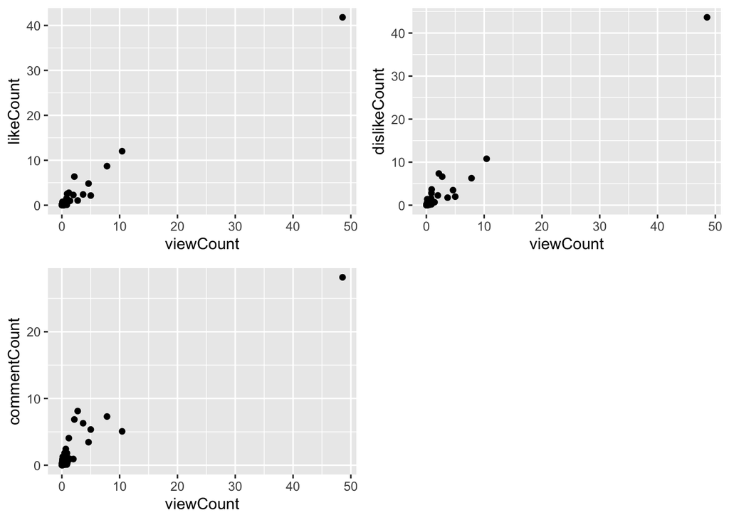

```r
p1 <-
  ggplot(data = videostats) +
  geom_point(aes(x = viewCount, y = likeCount))
p2 <-
  ggplot(data = videostats) +
  geom_point(aes(x = viewCount, y = dislikeCount))
p3 <-
  ggplot(data = videostats) +
  geom_point(aes(x = viewCount, y = commentCount))
grid.arrange(p1, p2, p3, ncol = 2)
```

Since the the distribution between commentCount and viewCount appears to have more nonlinearity, I thought it would be interesting to see what patterns emerge between comments and the pop_score. The plot appears as follows:

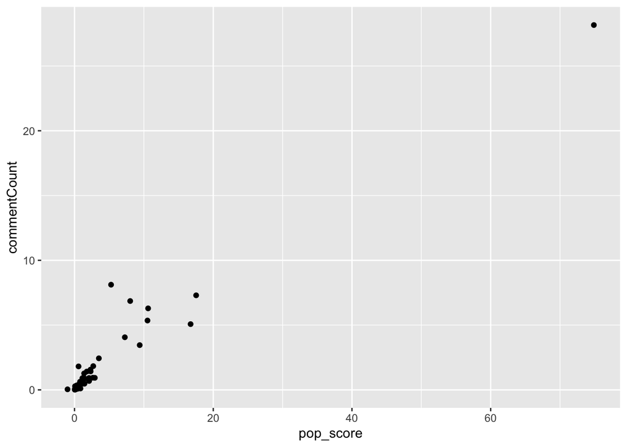

```r
p4 <-
  ggplot(data = videostats) +
  geom_point(aes(x = pop_score, y = commentCount))
print(p4)
```

**Examining Pop_Score via Histogram**

Of course, there is that outlier that requires further investigation. However, the plot seems to suggest that the more popular the artist is, the more likely it is to have commenting on their videos. Further investigation into the nature of the popularity of each artist is needed to understand these variables more deeply.

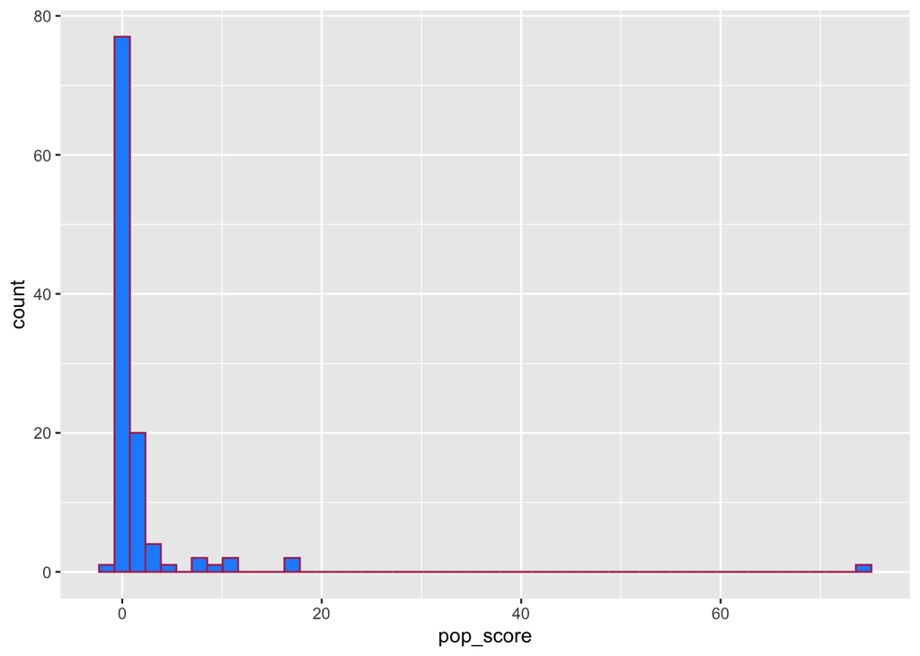

```r
 hist_plot <-
   videostats %>%
     ggplot(aes(x = pop_score)) +
     geom_histogram(color = "maroon", fill = "dodgerblue", bins = 50)
  print(hist_plot)
```

## Deeper Dive into the Data: Language Processing

In natural language processing, one of the objectives is to understand the interaction between human actors and the virtual platforms/computers used to capture it. In this project, I am interested in understanding the meaning introjected into the popularity of LaBelle, Houston and Carey more deeply by users of YouTube. By examining the comments, I am looking for meaningful information that might help flesh out the subjective experience of YouTube users in relationship to the stars they love and admire.

To help extract the meaningful information, I created a word cloud from users’ comments for each artist. Word clouds represent an efficient way to visualize the most important terms, based on word frequency. A close examination of the results of word clouds reveal attributes of the text not easily apparent by simply reading the comments text data itself.

*Word Cloud for Patti LaBelle:*

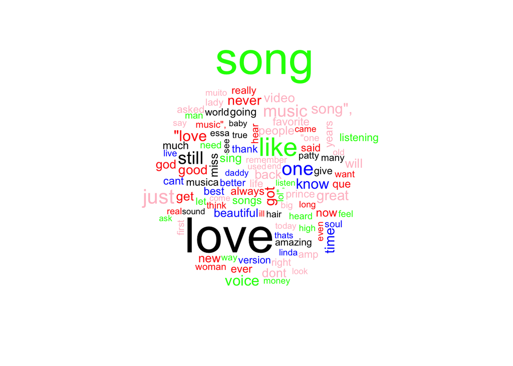

```r
wordcloud(names(word_freq_Pat)[which(regexpr("patti",
                                             names(word_freq_Pat)) == -1 &
                                       regexpr("labelle",
                                               names(word_freq_Pat)) == -1)],
          word_freq_Pat[which(regexpr("patti",
                                      names(word_freq_Pat)) == -1 &
                                regexpr("labelle",
                                        names(word_freq_Pat)) == -1)],
          max.words = 100, random.color = TRUE,
          colors = c("red", "pink", "blue", "green", "black"))
```

*Word Cloud for Whitney Houston:*

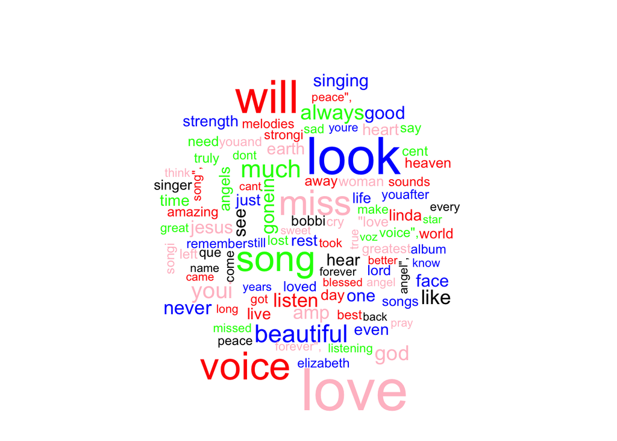

```r
wordcloud(names(word_freq_Whit)[which(regexpr("whitney",
                                              names(word_freq_Whit)) == -1 &
                                        regexpr("houston",
                                                names(word_freq_Whit)) == -1)],
          word_freq_Whit[which(regexpr("whitney",
                                       names(word_freq_Whit)) == -1 &
                                 regexpr("houston",
                                         names(word_freq_Whit)) == -1)],
          max.words = 100, random.color = TRUE,
          colors = c("red", "pink", "blue", "green", "black"))
```

*Word Cloud for Mariah Carey:*

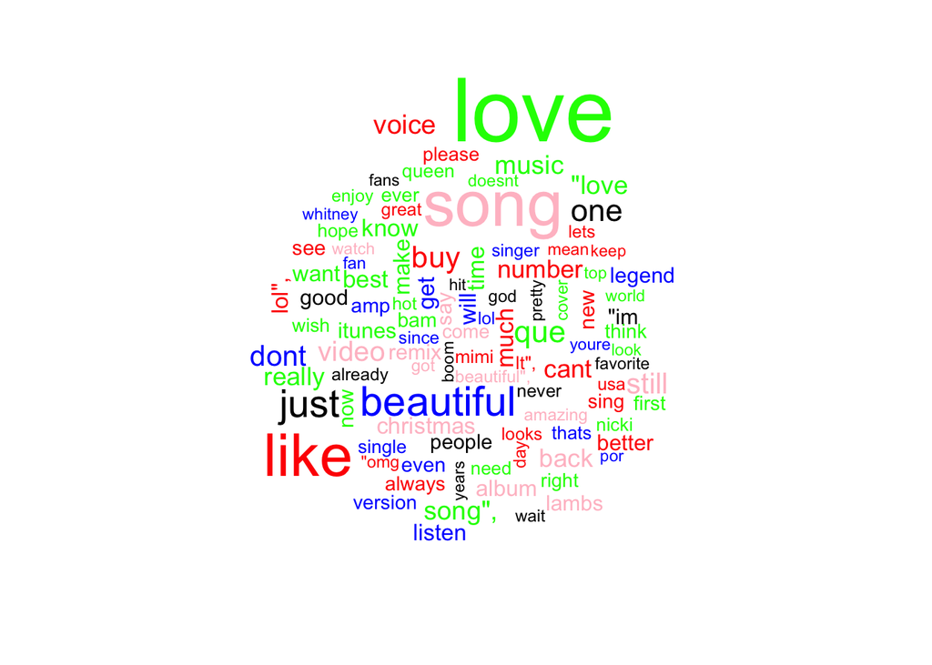

```r
wordcloud(names(word_freq_Mar)[which(regexpr("mariah",
                                             names(word_freq_Mar)) == -1 &
                                       regexpr("carey",
                                               names(word_freq_Mar)) == -1)],
          word_freq_Mar[which(regexpr("mariah",
                                      names(word_freq_Mar)) == -1 &
                                regexpr("carey",
                                        names(word_freq_Mar)) == -1)],
          max.words = 100, random.color = TRUE,
          colors = c("red", "pink", "blue", "green", "black"))
```

*Topic Modeling*

As a useful correlate to the word clouds, topic modeling was used. By examining word frequency and visualizing a hierarchical ordering of the words used in comments, it is possible to interpret how much weight to give certain terms over and against others. This information further helps provide context for the terms that appear in the word clouds.

*Patti LaBelle Topics*

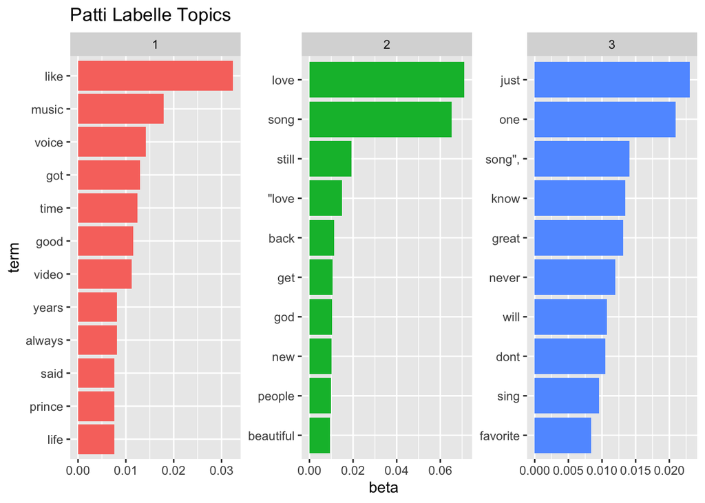

```r
tidy_comments_Pat <-
  word_freq_Pat %>%
  as.data.frame() %>%
  rename(count = names(.)[1]) %>%
  cbind(words = names(word_freq_Pat)) %>%
  mutate(words = as.character(words)) %>%
  mutate(id = seq(1, length(words))) %>%
  filter(regexpr("patti", words) == -1) %>%
  filter(regexpr("labelle", words) == -1)
rownames(tidy_comments_Pat) <- NULL
tidy_dtm_Pat <- cast_dtm(tidy_comments_Pat, words, id, count)
lda_Pat <-
  LDA(tidy_dtm_Pat, k = 3) %>%
  tidy() %>%
  group_by(topic) %>%
  top_n(10, beta) %>%
  ungroup() %>%
  arrange(topic, -beta)
lda_Pat %>%
  mutate(term = tidy_comments_Pat[match(term, tidy_comments_Pat$id), "words"]) %>%
  mutate(term = reorder(term, beta)) %>%
  ggplot(aes(term, beta, fill = factor(topic))) +
  geom_col(show.legend = FALSE) +
  facet_wrap(~ topic, scales = "free") +
  labs(title = "Patti Labelle Topics") +
  coord_flip()
```

*Whitney Houston Topics*

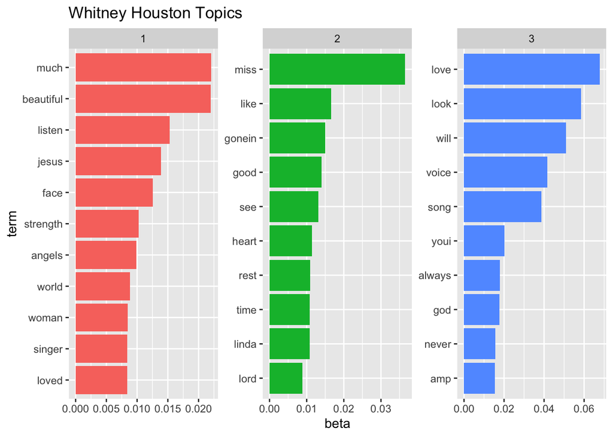

```r
tidy_comments_Whit <-
  word_freq_Whit %>%
  as.data.frame() %>%
  rename(count = names(.)[1]) %>%
  cbind(words = names(word_freq_Whit)) %>%
  mutate(words = as.character(words)) %>%
  mutate(id = seq(1, length(word_freq_Whit))) %>%
  filter(regexpr("whitney", words) == -1) %>%
  filter(regexpr("houston", words) == -1)
rownames(tidy_comments_Whit) <- NULL
tidy_dtm_Whit <- cast_dtm(tidy_comments_Whit, words, id, count)
lda_Whit <-
  LDA(tidy_dtm_Whit, k = 3) %>%
  tidy() %>%
  group_by(topic) %>%
  top_n(10, beta) %>%
  ungroup() %>%
  arrange(topic, -beta)
lda_Whit %>%
  mutate(term = tidy_comments_Whit[match(term, tidy_comments_Whit$id), "words"]) %>%
  mutate(term = reorder(term, beta)) %>%
  ggplot(aes(term, beta, fill = factor(topic))) +
  geom_col(show.legend = FALSE) +
  facet_wrap(~ topic, scales = "free") +
  labs(title = "Whitney Houston Topics") +
  coord_flip()
```

*Mariah Carey Topics*

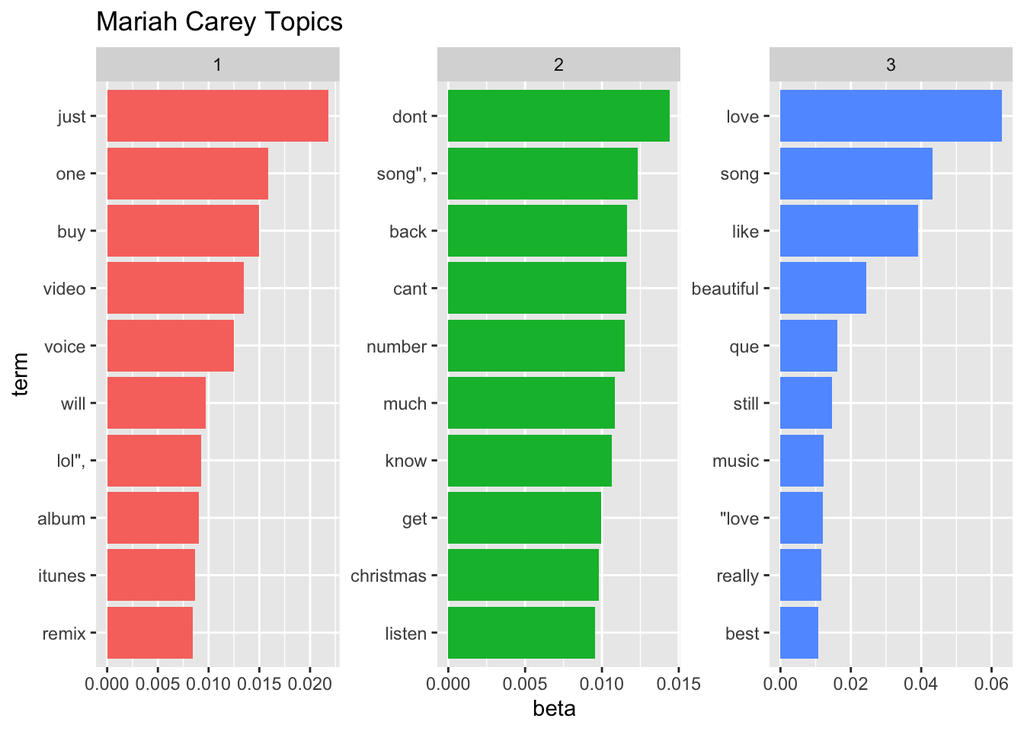

```r
tidy_comments_Mar <-
  word_freq_Mar %>%
  as.data.frame() %>%
  rename(count = names(.)[1]) %>%
  cbind(words = names(word_freq_Mar)) %>%
  mutate(words = as.character(words)) %>%
  mutate(id = seq(1, length(words))) %>%
  filter(regexpr("mariah", words) == -1) %>%
  filter(regexpr("carey", words) == -1) %>%
  filter(regexpr("mimi", words) == -1)
rownames(tidy_comments_Mar) <- NULL
tidy_dtm_Mar <- cast_dtm(tidy_comments_Mar, words, id, count)
lda_Mar <-
  LDA(tidy_dtm_Mar, k = 3) %>%
  tidy() %>%
  group_by(topic) %>%
  top_n(10, beta) %>%
  ungroup() %>%
  arrange(topic, -beta)
lda_Mar %>%
  mutate(term = tidy_comments_Mar[match(term, tidy_comments_Mar$id), "words"]) %>%
  mutate(term = reorder(term, beta)) %>%
  ggplot(aes(term, beta, fill = factor(topic))) +
  geom_col(show.legend = FALSE) +
  facet_wrap(~ topic, scales = "free") +
  labs(title = "Mariah Carey Topics") +
  coord_flip()
```

*Sentiment Analysis*

In addition to exploring word clouds, this project takes advantage of predefined lexicon dictionaries using the R packages tidytext and textdata. Sentiment analysis aims to determine the opinion and subjective impression of particular texts. By employing sentiment analysis, I am able to calculate a sentiment score for each artist. This score will provide a useful point of reference for later triangulation with the results of topic modeling. This project uses word-level sentiment analysis.

*Patti LaBelle Sentiment Analysis*

```r
tokensPat <-
  unnest_tokens(all_comments_clean %>% filter(video_id %in% videosPat$video_id), word, comment)
sentiment_Pat <-
  tokensPat %>%
  inner_join(get_sentiments("loughran")) %>% # pull out only sentiment words
  count(sentiment) %>% # count the # of positive & negative words
  spread(sentiment, n, fill = 0) %>% # made data wide rather than narrow
  mutate(sentiment = 100 * (positive - negative) / (positive + negative))
sentiment_Pat
```

```
## # A tibble: 1 x 5
##   litigious negative positive uncertainty sentiment
##       <dbl>    <dbl>    <dbl>       <dbl>     <dbl>
## 1        10      137      333          53      41.7
```

*Whitney Houston Sentiment Analysis*

```r
tokensWhit <-
  unnest_tokens(all_comments_clean %>% filter(video_id %in% videosWhit$video_id), word, comment)
sentiment_Whit <-
  tokensWhit %>%
  inner_join(get_sentiments("loughran")) %>% # pull out only sentiment words
  count(sentiment) %>% # count the # of positive & negative words
  spread(sentiment, n, fill = 0) %>% # made data wide rather than narrow
  mutate(sentiment = 100 * (positive - negative) / (positive + negative))
sentiment_Whit
```

```
## # A tibble: 1 x 6
##   constraining litigious negative positive uncertainty sentiment
##          <dbl>     <dbl>    <dbl>    <dbl>       <dbl>     <dbl>
## 1            1        36     1136     1155         166     0.829
```

*Mariah Carey Sentiment Analysis*

```r
tokensMar <-
  unnest_tokens(all_comments_clean %>% filter(video_id %in% videosMar$video_id), word, comment)
sentiment_Mar <-
  tokensMar %>%
  inner_join(get_sentiments("loughran")) %>% # pull out only sentiment words
  count(sentiment) %>% # count the # of positive & negative words
  spread(sentiment, n, fill = 0) %>% # made data wide rather than narrow
  mutate(sentiment = 100 * (positive - negative) / (positive + negative))
sentiment_Mar
```

```
## # A tibble: 1 x 7
##   constraining litigious negative positive superfluous uncertainty
##          <dbl>     <dbl>    <dbl>    <dbl>       <dbl>       <dbl>
## 1           38       272     1827     6768           5         857
## # … with 1 more variable: sentiment <dbl>
```

## Discussion

For this project, I really wanted to understand the ways in which fans constructed “the popular” by way of their active social media behavior. The above data exploration provides a snapshot into the interactive and interpretive nature of fan bases. It is through the exploration of actual users’ comments that a model of popularity and its associated emotional impressions emerge.

**Word Clouds**

In all of the word clouds for the three artists, there is an overlap in the representation of terms like: song, amazing, beautiful, sing, voice, and love. This overlap in terms certainly suggest that fans require beautiful singing voices and a love for both the songs and quality of the singing for an artist to be considered “popular.” However, one might assume this is the case: we didn’t need data science to tell us that. Rather, we desire for data science to offer us insights we perhaps would have never considered previously. Therefore, word clouds are the most helpful if we shift our gaze to note the occurrences of unique and unusual terms.

In Patti LaBelle’s word cloud, some of the words that stand out are: big, world, soul, god, hair, years and time. These terms seem to point to something timeless about a popular artist, perhaps suggesting a quality that is big or beyond this world. Of course, the term “big” could be associated with “hair” as Patti LaBelle was known to don especially big 1980s hair styles. Even though this detail may seem trivial, perhaps it is a significant feature for predicting fan-based measures of popularity. Many celebrities sport a signature style and become well-known for their carefully cultivated “look.” That such an attribute registers in the minds of fans indicates the multi-dimensional appraisal processes that occur and that popularity of singers is not solely about how the voice sounds. However, “big” could also represent the perceived “bigness” of Patti, herself, in terms of status and her long running career in music. The terms, “time” and “years” certainly point to longevity. However, what is most striking in Patti’s word cloud is the term “god,” which recalls the introduction of my project and its concern with the ways in which audience members construct “the divine” (here, understood as “the diva”). Perhaps “big” is connected to the term “god” and, if so, popularity, as measured by the commenting behavior of YouTube users, comes to mean something beyond mere human experience–something that is greater and more awesome in nature.

In Whitney Houston’s word cloud, some of the more intriguing terms that stand out are: jesus, angel, sweet, peace, pray, earth, heaven and blessed. Similar to the word cloud for Patti LaBelle, Whitney’s word cloud seems to be associated with otherworldly terms. However, Whitney’s words seem to be qualitatively different from Patti’s. There’s a softer edge to the terms, pointing more towards how Whitney makes the audience FEEL, perhaps even, inside themselves. Perhaps audiences feel at peace, or if they had been visited by an angel, or even blessed. Or, perhaps, these terms may signify that they think Whitney, herself, is an angel and that Whitney is blessed. In any event, popularity comes to again mean something that is transcendent. Yet, these terms can also be said to be pointing to something that is equally as immanent–the term “earth” appears, perhaps bringing the notion of “the angelic” to the earth realm, perhaps even implying that Whitney, herself, is “down to earth.” In this interpretation, it would seem that audiences appreciate the type of popularity that seems “larger than life” on one level but all the more assessible on another level. Perhaps “the popular” are indeed the “earth angels.”

Finally, in Mariah Carey’s word cloud, some of the unique terms are: legend, christmas, top, queen, and hot. The word “god” also appears in Mariah’s word cloud, but unlike the soul-inflected language of both Patti’s and Whitney’s word clouds, the themes in Mariah’s word cloud seem to point less toward the otherworldly and more toward the physical and material reality permeating and surrounding Mariah’s work. The terms, “legend” and “christmas” might be associated as Mariah is known to create new trends that have staying power, as in being one of only a handful of popular artists to record a christmas song that enjoys yearly plays alongside other legendary holiday “classics”. The term “top” stands out because while it points to something hierarchical, it does not necessarily have to point to something as high as the gods. The term “hot” could refer to Mariah’s music, sound or looks. It is an interesting term in this context because even as Mariah seems to be more “of this world” she is still a luminary. And, just as the sun, our highest luminary in the sky, is close enough to be considered “in this world,” (in the same way that “queens” are “in this world”) one still ought not to get too close, lest one gets burned by its heat. So, the word cloud seems to point to a definition of popularity that is intimate even as it is shrouded in an aura that demands audiences keep their distance.

**Topic Modeling**

The previous discussion of the word clouds reveals some compelling associations however, interpreting word clouds is an imprecise exercise. For this reason, triangulating the interpretions of the word clouds with topic modeling provides another layer of analysis. Topic analysis returns clusters of similar terms and interpreting the possible meaning behind the clusters is the chief objective of topic modeling. For the purposes of this project, there are 3 topics per artist.

Overall, it would seem that there is some level of synergy between the outputs of the word clouds and the topic models.

**Sentiment Analysis**

## Conclusion

This study was interested in discerning the relationship between social media users’ activity and notions of popularity which point to contemporary conceptualizations of “the sacred”. In particular, this project is grounded on the assumption that music audiences, for instance, play an active and dynamic role in the cultivation of contemporary expression of sacredness through their social media commenting. Employing Robin Sylvan’s view that popular music contains within it intense religious significance understood in the context of audiences’ emotional experiences, this project uses data science to explore the confluence of popularity, perceived value, sacred/religious themes and sentiment. What is fascinating in the results of this study is that text mining and sentiment analysis seems to confirm Sylvan’s claims through the various references to “God,” “soul,” “heaven,” “angels,” etc.

In sum, popularity seems to boil down to three qualities:

1. it contains bigness and timelessness (it expands the sense of the ordinary)
2. it is both transcendent and immanent (it reaches beyond and within human beings)
3. it is reflective of legendary status within the contemporary world (it is set apart)

Interestingly enough, these three qualities might have been used to describe any number of significant religious leaders for whom many of the world’s religions are named. The fact that these qualities have been gleaned from word clouds, topic models and sentiment scores for three female R&B singers reveals the ongoing desire for the human heart to be connected with these ideals. The realization of the emotional importance of connection to these values is evidenced by the intensity of sorrow and grief when this contact is somehow severed (as in the example of audiences who miss and mourn Whitney Houston in her untimely death.) What this project ultimately shows is that people are motivated to act toward their highest values and to select symbolic representations of such values from within the cultural milieu. Because of the emotional signficance of selecting a symbol of one’s sacred, it would seem that commenting, liking, sharing, and similar activities should be understood not as trivial distractions but rather as a contemporary meaning-making system of great import.

## Limitations of the Project

While this project attempts to discern the relationship between commenting behavior and popularity associated with Patti LaBelle, Whitney Houston, and Mariah Carey, it comes with several limitations. The first limitation involves my use of the Tuber package itself. The Tuber package is great for pulling data from YouTube. However, in its current form, my dataset includes all the videos posted on a particular channel. The code I employed to create the dataset casted a wide net, including some video content that is not relevant to my specific research question. While I believe the data is rich, it is not perfect. Filtering the videos on the channel id proved to be beyond the scope of this current research project. Because of the extra video content, the level of specificity is limited in this project.

Another limitation involves the level of filtering when creating word clouds and topic models. As text mining is not necessarily a precise process, it requires a flexible approach when deciding which terms to remove from consideration. Some of the words returned in the word clouds and topic models did not seem very useful or descriptive. If performed again, I would consider doing several rounds of filtering to ensure that the terms returned in the analysis truly paint a descriptive and relevant story.

As an extension to the last point, using one-word topic modeling comes with some degree of limitation as well. While the one-word topic model is simple and relatively assessible, a multiple-words model might provide more overall contextualization of the themes.

Finally, this project is limited in terms of the balancing of the videos, comments, and statistics returned for each YouTube channel. Because some channels hosted more videos than others and because some videos had more commenting than others, the data returned for each artist lacked symmetry. While adjustments were made in the code to account for this imbalance, perhaps an alternative plan for handling such matters might have been employed.

## Implications and Recommendations for Further Research

This project points to the growing importance of text mining and sentiment analysis. As indicated in the above conclusion, data science reveals that social media commenting and interactive behavior might just be more influential and impactful as a meaning-making system than anyone suspects. Of course, marketing and industry firms already understand the importance of harnassing such information in order to match products and services to ideal target audiences. However, this project also points to the ways in which text mining and sentiment analysis can be helpful to public administration, social work, psychological counseling, and religious institutions. As a meaningful tool to gauge and understand people’s behavior, data science offers these institutions an opportunity to assess what people truly value, which then, can be correlated to how people truly feel about themselves in relationship to their deeply held values.

I would recommend to those who wish to conduct similar research of this nature to do the following for even better results:

1. Have a succinct and well-defined research question.
2. To create a dataset with specific videos in mind, instead of using an entire YouTube channel.
3. To delve beyond the one-word topic analysis to provide a richer context surrounding the relevant themes.

In conclusion, the applications for a text mining and sentiment analysis project are endless. Overall, it enables researchers to capture the evolution of thought and emotion of quickly changing human beings as they engage and impact their world.